# Exemples d’exercices pour l’évaluation individuelle N2- Corrigé

Frédérique Leblanc

2023-02-19

On travaille avec les données mtcars : dataframe disponible dans la librairie de base de R

# question 1 :

On remplit le tableau à l’aide des résumés numériques produits dans le “chunck” suivant

```r
y<-mtcars$disp #echantillon de disp taille nY=32
x<-mtcars$cyl  #echantillon de disp taille nX=32
mean(y); var(y)*31/32; var(y)
```

```
## [1] 230.7219
```

```
## [1] 14880.77
```

```
## [1] 15360.8
```

```r
quantile(y); sd(y)
```

```
##      0%     25%     50%     75%    100%
##  71.100 120.825 196.300 326.000 472.000
```

```
## [1] 123.9387
```

# question 2

Comme ici l’échantillon est de taille moyenne, il est raisonnable de s’assurer qu’il provient d’une variable $Y$ qui suit une loi normale. Le plus efficace pour apprécier la normalité d’un échantillon est d’utiliser le quantile-quantile plot (avec des quantiles théoriques calculés sur la loi normale) avec la fonction $\texttt{qqnorm}$ auquelle on ajoutera la droite qui passe par les deux points $(q_{0.25},\hat{q}_{0.25})$ et $(q_{0.75},\hat{q}_{0.75})$ avec $\texttt{qqline}$ :

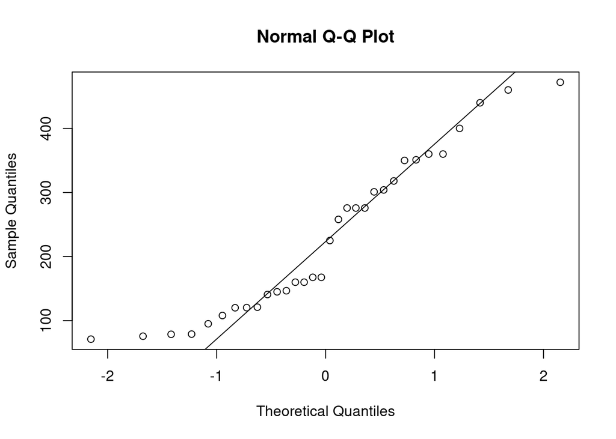

```r
qqnorm(y); qqline(y)
```

Difficile d’accepter la normalité de $Y$ à cause des points aux deux extremités. Ce n’est pas très grave ici puisque l’échantillon est de taille ($n_Y=32$) suffisante pour pouvoir utiliser les résultats asymptotiques et se passer de la normalité de l’échantillon.

# question 3

Comme l’échantillon n’est pas gaussien (normal) mais de taille suffisante la procédure $\texttt{t.test}$ peut-être utilisée : elle fournira des IC de niveaux asymptotiques :

```r
mean(y);var(y)
```

```
## [1] 230.7219
```

```
## [1] 15360.8
```

```r
t.test(y) #pour le niveau asympt 95%
```

```
##
##  One Sample t-test
##
## data:  y
## t = 10.531, df = 31, p-value = 9.189e-12
## alternative hypothesis: true mean is not equal to 0
## 95 percent confidence interval:
##  186.0372 275.4065
## sample estimates:
## mean of x
##  230.7219
```

```r
t.test(y,conf.level=0.8) #pour le niveau asympt 80%
```

```
##
##  One Sample t-test
##
## data:  y
## t = 10.531, df = 31, p-value = 9.189e-12
## alternative hypothesis: true mean is not equal to 0
## 80 percent confidence interval:
##  202.0322 259.4115
## sample estimates:
## mean of x
##  230.7219
```

# question 4

La variable $X$ (cyl) est discrète. On représentera sa répartition observée avec un diagramme en barres ($\texttt{barplot}$) ou un diagramme en secteurs ($\texttt{pie}$). Attention ces fonctions doivent être appliquées sur les données en fréquences ($\texttt{table(x)/length(x)}$) et pas sur les données brutes ($\texttt{x}$) pour $\texttt{barplot}$ et sur les données en effectifs ($\texttt{table(x)}$) pour $\texttt{pie}$ :

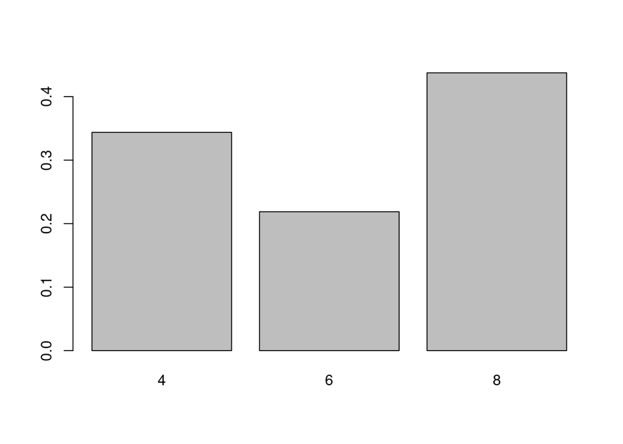

```r
barplot(table(x)/32)
```

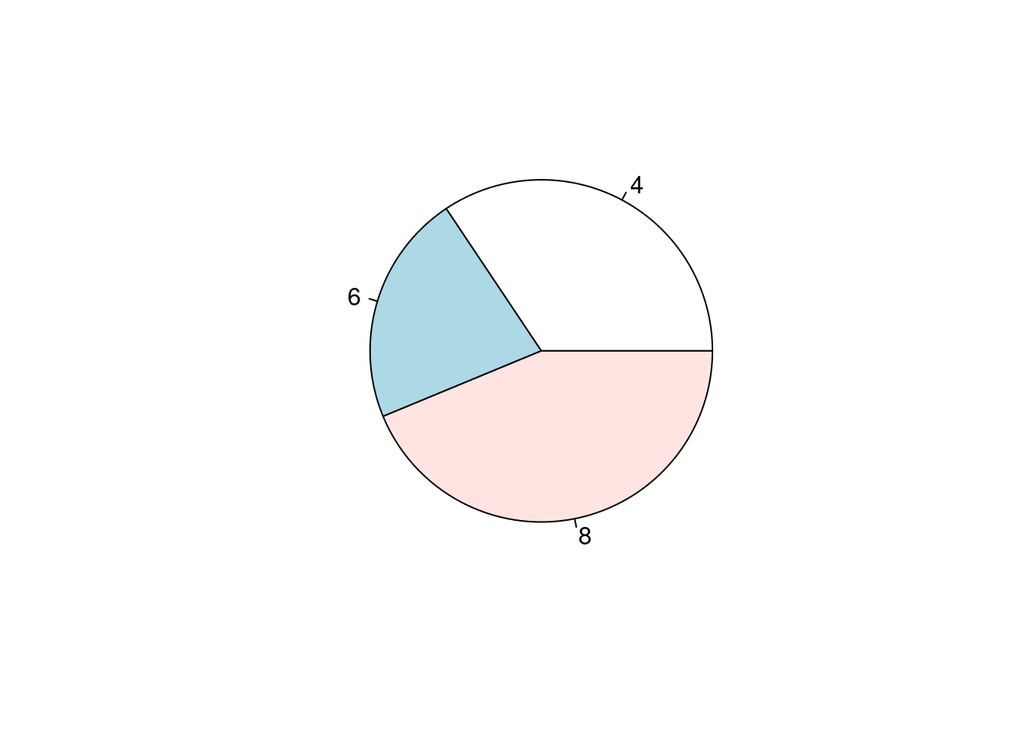

```r
pie(table(x))
```

Les bonnes réponses sont donc 2) et 3)

# question 5

Le graphique proposé qui décrit la répartition observée de $Y$ qui est une variable continue (donc histogramme) s’obtient avec la liste d’instructions suivante :

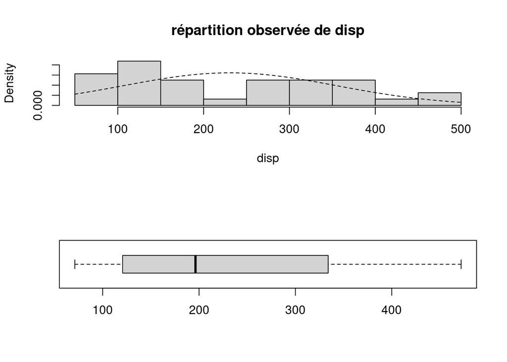

```r
par(mfrow=c(2,1)) #part en2 lignes et une colonne
hist(y,prob=T,main="répartition observée de disp",xlab="disp")
curve(dnorm(x,mean(y),sd(y)),add=TRUE,lty=2)
boxplot(y,horizontal=TRUE)
```

# question 6

Il n’y a pas de procédure automatique dans la librairie de base de R pour faire un test sur la variance de l’échantillon. On fait donc les calculs à la main (voir TD) avec
$$T=\frac{nS^2_Y}{\sigma_0^2}~~~~\mbox{et}~~~pval=min(2\cdot
P({\cal X}^2_{n-1}<Tcalc),2\cdot (1-P({\cal
X}^2_{n-1}>Tcalc)))$$

```r
Tcalc<-31*var(y)/15000; pval=min(2*pchisq(Tcalc,31),2*(1-pchisq(Tcalc,31)))
```

Au niveau $\alpha=5\%$ on ne rejette pas ${\cal H}_0$ puisque $\alpha=5\%<pval$. Donc si on voulait faire un test sur $\mu_Y$ on pourrait supposer $\sigma^2_Y=15000$ (donc connu).

# question 7

```r
tcalc<-sqrt(32)*(mean(y)-280)/sd(y); pval=2*pt(tcalc,31)
```

On obtient $tcalc=-2.25$ et $pval=3.17\%$.

On peut donc valider $\mu_Y\neq 280$ pour tout risque de se tromper supérieur à $3.17\%$.

# question 8

Un quantile d’ordre $p$ ($p\in[0,1]$) d’une variable normale centrée réduite se calcule avec la fonction de R $\texttt{qnorm}$ et comme il s’agit d’une densité symétrique on sait aussi que $q_p=-q_{1-p}$. Parmi les solutions proposées on obtient le résultat avec 1) ou avec 5)

# question 9

La probabilité qu’une variable normale soit inférieure ou égale à x se calcule avec la fonction $\texttt{pnorm}$ et comme $P(X\leq 0)=0.5$ :
$$P(X\leq x)=P(X\leq
0)+P(X\in[0,x])=0.5+P(X\in[0,x]), \forall x\geq 0.$$
Parmi les solutions proposées on obtient le résultat avec 1) et 2)